# edld610_lab3

Cameron Kay, Lea Frank, Ashley Miller

1/30/2019

#### 1) Start with the google trends

- Visualize the change in trends for each hurricane over time in one plot with three scales. Map color to a discrete scale.

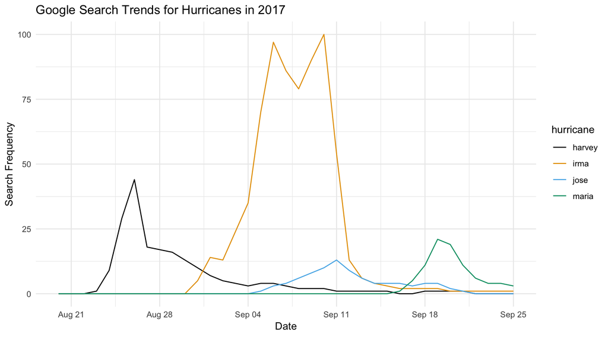

```r
google <- google_trends %>%
  gather(key = "hurricane", value = "trends", -1) %>%
  separate(col = "hurricane", into = c("tmp1","hurricane","tmp2")) %>%
  select(-tmp1, -tmp2)

google %>%
  ggplot(aes(x = date, y = trends, color = hurricane)) +
  geom_line() +
  theme_minimal() +
  scale_color_colorblind() +
  labs(title = "Google Search Trends for Hurricanes in 2017",
       y = "Search Frequency",
       x = "Date",
       fill = "Hurricane")
```

- Visualize the trends again, this time using geom_ribbon, setting the ymin to 0.

[figure not shown]

```r
google %>%
  ggplot(aes(x = date, y = trends, color = hurricane)) +
  geom_ribbon(aes(ymin = 0, ymax = trends, fill = hurricane), alpha = .5) +
  theme_minimal() +
  scale_fill_colorblind() +
  scale_color_colorblind() +
  labs(title = "Google Search Trends for Hurricanes in 2017",
       y = "Search Frequency",
       x = "Date")
```

```r
# I couldn't figure out how to change the legend title without creating an extra legend for the other scale (color or fill)
```

- Visualize the same relation, but change the scales so color is mapped to a continuous scale.

[figure not shown]

```r
google %>%
  ggplot(aes(x = date, y = hurricane, color = trends)) +
  geom_point(aes(size = trends)) +
  scale_color_distiller(palette = "Purples", direction = 1) +
  theme_minimal() +
  labs(title = "Google Search Trends for Hurricanes in 2017",
       y = "Hurricanes",
       x = "Date") +
  guides(color = guide_legend(title = "Search Frequency"), size = guide_legend(title = "Search Frequency"))
```

- Create a data frame that includes the dates that each hurricane made landfall. Annotate one of your first two plots to include these reference points with vertical lines. The hurricanes made landfall on (approximately) the following days: Harvey: August 25, 2017 Irma: September 10, 2017 Jose: Did not make landfall Maria: September 20, 2017

[figure not shown]

```r
hc_dates <- tibble(hurricane = c("harvey","irma","jose","maria"),
                   landfall = lubridate::ymd(c("2017-08-25","2017-09-10",NA,"2017-09-20")))

google <- left_join(google, hc_dates, by = "hurricane")

google %>%
  ggplot(aes(x = date, y = trends, color = hurricane, fill = hurricane)) +
  geom_ribbon(aes(ymin = 0, ymax = trends), alpha = .5) +
  geom_vline(aes(xintercept = landfall, color = hurricane), size = .5) +
  theme_minimal() +
  scale_fill_colorblind() +
  scale_color_colorblind() +
  labs(title = "Google Search Trends for Hurricanes in 2017",
       y = "Search Frequency",
       x = "Date")
```

- Make any final modifications to the plot you’d like to communicate the information as effectively as possible

[figure not shown]

```r
google$hurricane <- factor(google$hurricane, labels = c("Harvey","Irma","Jose","Maria"))
colnames(google)[2] <- "Hurricane"

fig_cols <- colorblind_pal()(4)

google %>%
  ggplot(aes(x = date, y = trends, fill = Hurricane)) +
  geom_ribbon(aes(ymin = 0, ymax = trends), alpha = .6) +
  #geom_vline(aes(xintercept = landfall, color = Hurricane),
  #           size = .3, linetype = "dashed") +
  theme_minimal() +
  scale_fill_colorblind() +
  scale_color_colorblind() +
  labs(title = "Google Search Trends for Hurricanes in 2017",
       subtitle = "Date of landfall indicated by dashed line",
       y = "Search Frequency",
       x = "Date") +
  geom_segment(x = hc_dates$landfall[1], y = 0, xend = hc_dates$landfall[1], yend = 100,
           color = fig_cols[1], size = .3, linetype = "dotted") +
  geom_segment(x = hc_dates$landfall[2], y = 0, xend = hc_dates$landfall[2], yend = 100,
           color = fig_cols[2], size = .3, linetype = "dotted") +
  geom_segment(x = hc_dates$landfall[4], y = 0, xend = hc_dates$landfall[4], yend = 100,
           color = fig_cols[4], size = .3, linetype = "dotted") +
  annotate(geom = "text", y = 105, x = hc_dates$landfall[1], label = "Aug 25") +
  annotate(geom = "text", y = 105, x = hc_dates$landfall[2], label = "Sep 10") +
  annotate(geom = "text", y = 105, x = hc_dates$landfall[4], label = "Sep 20")
```

#### 2) Replicate the “National cable news networks” plot using the tv_states data. Don’t worry about all the labels. Try to match the colors but don’t worry about getting them exact.

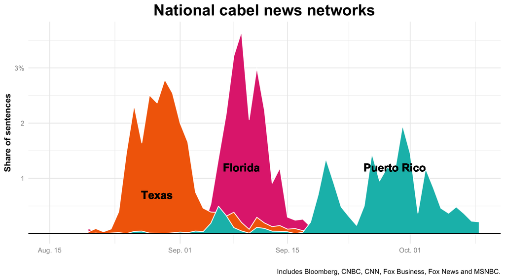

```r
#load data
tv_data <- tv_states %>%
  gather(location, share, florida:puerto_rico)

tv_data$location <- factor(tv_data$location, levels = c("florida", "texas", "puerto_rico"))

dateVec <- as.Date(c("2017-08-15", "2017-08-29", "2017-09-01", "2017-09-09", "2017-09-29", "2017-10-01", "2017-10-10"))

ggplot(tv_data, aes(x = date, y = share, fill = location)) +
  geom_area(color = "white",
            position = "identity") +
  scale_fill_manual(values = c("#E2327D", "#F36A05", "#0BBCB8")) +
  theme_minimal() +
  labs(title = "National cabel news networks",
       x = "",
       y = "Share of sentences",
       caption = "Includes Bloomberg, CNBC, CNN, Fox Business, Fox News and MSNBC.") +
  theme(plot.title = element_text(face = "bold", hjust = 0.5, size = 20),
        legend.position = "none",
        axis.title = element_text(size = 11, face = "bold"),
        axis.text = element_text(colour = "gray58")) +
  geom_hline(yintercept = 0) +
  scale_x_date(limits = c(min(dateVec), max(dateVec)),
               date_labels = "%b. %d") +
  scale_y_continuous(breaks = c(1, 2, 3),
                     label = c("1", "2", "3%"),
                     limits = c(0, NA)) +
  geom_text(y = 0.7, x = dateVec[2],
         label = "Texas", fontface = 2, size = 5) +
  geom_text(y = 1.2, x = dateVec[4],
           label = "Florida", fontface = 2, size = 5) +
  geom_text(y = 1.2, x = dateVec[5],
           label = "Puerto Rico", fontface = 2, size = 5)
```

#### 3) Use the comic_characters dataset to visualize the proportion of different genders using at least **three** different methods. With your final visualization, make any additional modifications you think would help reduce the cognitive load neccessary to comprehend the figure.

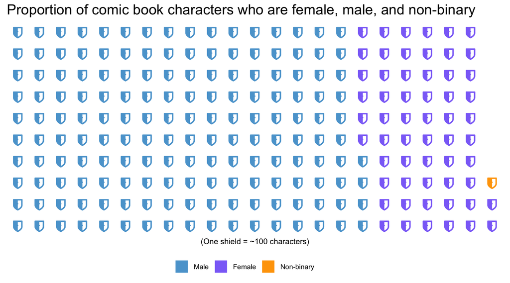

```r
# create new column with female, male, and nonbinary
char_data <- comic_characters %>%
  filter(!is.na(sex)) %>%
  mutate(sex           = gsub(" Characters", "", sex),
         three_cat_sex = case_when(sex == "Female" ~ "Female",
                                   sex == "Male"   ~ "Male",
                                   TRUE            ~ "Non-binary"))

# count number of instances of each sex
char_3c <- char_data %>%
  count(three_cat_sex) %>%
  mutate(proportion = n / sum(n),
         percent    = round(proportion * 100, 2),
         percent    = paste(as.character(percent), "%", sep = ""),
         n_100      = round(n / 100)) %>%
  arrange(desc(proportion))

# create a named vector
sex_count <- char_3c$n_100
names(sex_count) <- char_3c$three_cat_sex

# create waffle plot
waffle(parts = sex_count,
       use_glyph = "shield",
       rows = 10,
       glyph_size = 6,
       title = "Proportion of comic book characters who are female, male, and non-binary",
       xlab = "(One shield = ~100 characters)",
       colors = c("#5BA4D3", "#8C72F7", "#FFA404"),
       legend_pos = "bottom")
```

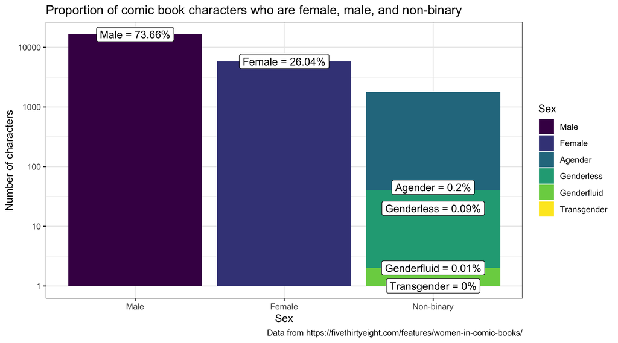

```r
# produce bar plot
char_data %>%
  count(sex) %>%
  mutate(proportion = n / sum(n),
         percent    = round(proportion * 100, 2),
         percent    = paste(as.character(percent), "%", sep = ""),
         three_cat_sex = case_when(sex == "Female" ~ "Female",
                                   sex == "Male"   ~ "Male",
                                   TRUE            ~ "Non-binary")) %>%
    ggplot(aes(x = fct_reorder(three_cat_sex, desc(proportion)), y = n, fill = fct_reorder(sex, desc(n)))) +
      geom_bar(stat = 'identity', position = 'stack') +
      scale_fill_viridis_d() +
      scale_y_log10() +
      geom_label(aes(label = paste(sex, "=", percent)), fill = "white") +
      labs(title   = "Proportion of comic book characters who are female, male, and non-binary",
           y       = "Number of characters",
           x       = "Sex",
           fill    = "Sex",
           caption = "Data from https://fivethirtyeight.com/features/women-in-comic-books/") +
      theme_bw()
```

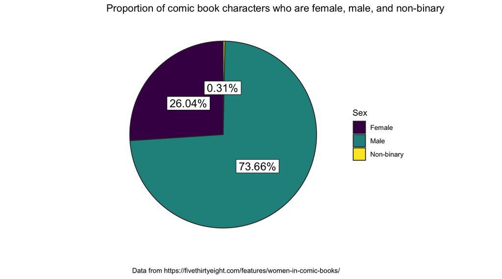

```r
# produce pie plot
ggplot(char_3c, aes(x = "", y = proportion, fill = three_cat_sex)) +
  geom_bar(stat = "identity", width = 1, color = "gray20") +
  coord_polar("y", start = 0) +
  scale_fill_viridis_d() +
  geom_label(aes(label = percent),
             label.r = unit(0.001, "lines"),
             fill = "white",
             size = 5,
             position = position_stack(vjust = .5)) +
  labs(title   = "Proportion of comic book characters who are female, male, and non-binary",
       x       = "",
       y       = "",
       fill    = "Sex",
       caption = "Data from https://fivethirtyeight.com/features/women-in-comic-books/") +
  theme_classic() +
  theme(axis.line = element_blank(),
        axis.text = element_blank(),
        axis.ticks = element_blank())
```